# Estimation of nu

Daniel P. Palomar The Hong Kong University of Science and Technology (HKUST)

2020-05-12

> This report explores the convergence of $\nu$ for different estimation methods in package [`fitHeavyTail`](https://CRAN.R-project.org/package=fitHeavyTail).

Let’s define the parameters for the generation of the multivariate Student’s $t$ distribution:

```r
library(mvtnorm)  # package for multivariate t distribution
set.seed(137)

N <- 20   # number of variables
T <- 60   # number of observations
nu <- 4   # degrees of freedom for tail heavyness
mu <- rep(0, N)
U <- t(rmvnorm(n = round(0.3*N), sigma = 0.1*diag(N)))
Sigma_cov <- U %*% t(U) + diag(N)  # covariance matrix with factor model structure
Sigma_scatter <- (nu-2)/nu * Sigma_cov
```

To warm up, let’s consider the following estimators for $\nu$:

- based on the kurtosis directly
- based on MLE w.r.t. $\nu$ assuming a diagonal sample covariance matrix
- idem but resampling for additional stability
- iterative estimation based on the EM algorithm with the previous three initial points.

```r
library(fitHeavyTail)

X <- rmvt(n = T, delta = mu, sigma = Sigma_scatter, df = nu)  # generate data

# direct methods
nu_kurtosis           <- fit_mvt(X, nu = "kurtosis")$nu
nu_mle_diag           <- fit_mvt(X, nu = "MLE-diag")$nu
nu_mle_diag_resampled <- fit_mvt(X, nu = "MLE-diag-resampled")$nu

# EM with different initial points
EM_nu0_true               <- fit_mvt(X, nu = "iterative", initial = list(nu = nu))$nu
EM_nu0_kurtosis           <- fit_mvt(X, nu = "iterative", initial = list(nu = "kurtosis"))$nu
EM_nu0_mle_diag           <- fit_mvt(X, nu = "iterative", initial = list(nu = "MLE-diag"))$nu
EM_nu0_mle_diag_resampled <- fit_mvt(X, nu = "iterative", initial = list(nu = "MLE-diag-resampled"))$nu

rbind("nu_true" = nu, nu_kurtosis, nu_mle_diag, nu_mle_diag_resampled,
      EM_nu0_true, EM_nu0_kurtosis, EM_nu0_mle_diag, EM_nu0_mle_diag_resampled)
```

```
#>                               [,1]
#> nu_true                   4.000000
#> nu_kurtosis               5.135461
#> nu_mle_diag               3.490499
#> nu_mle_diag_resampled     3.875287
#> EM_nu0_true               3.083620
#> EM_nu0_kurtosis           3.083620
#> EM_nu0_mle_diag           3.083620
#> EM_nu0_mle_diag_resampled 3.083620
```

We can observe the convergence of $\nu$:

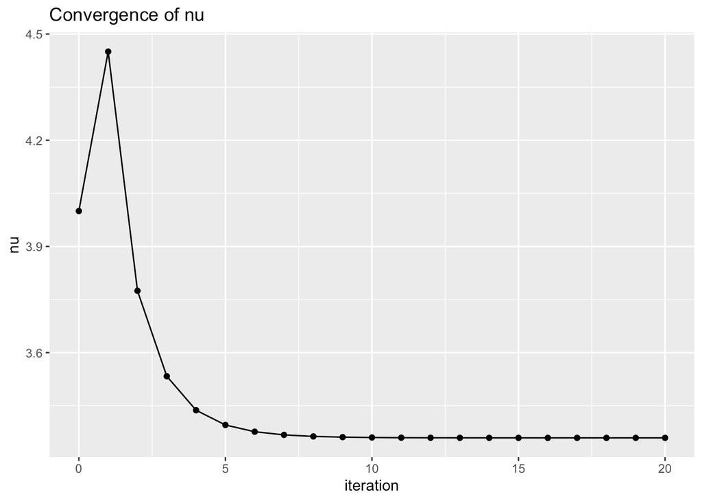

```r
fitted <- fit_mvt(X, nu = "iterative", initial = list(nu = nu), nu_iterative_method = "theta-0", return_iterates = TRUE)
fitHeavyTail:::plot_convergence(fitted)$nu
```

We now run 100 Monte Carlo simulations.

The results can be seen in the following boxplots:

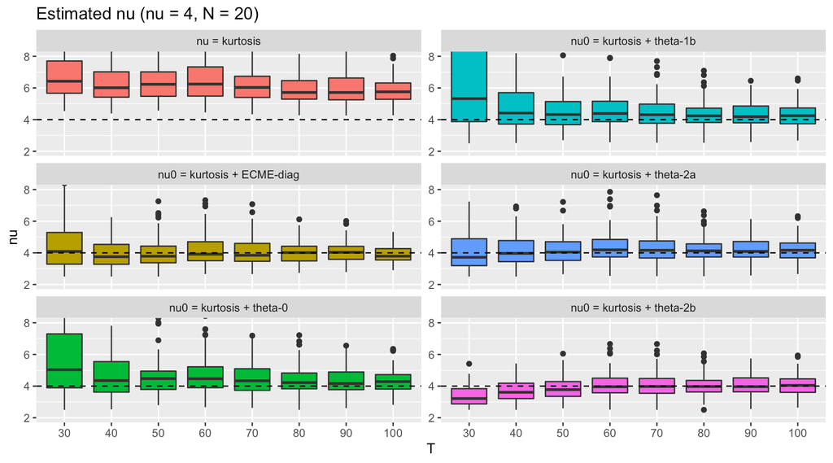

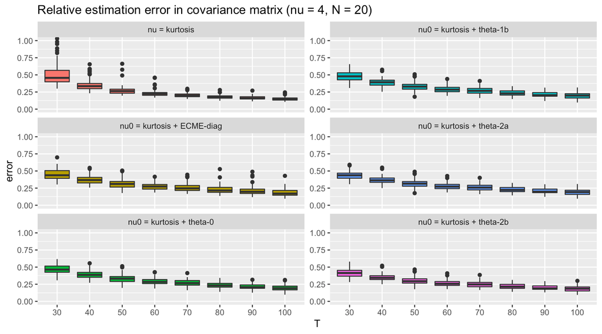

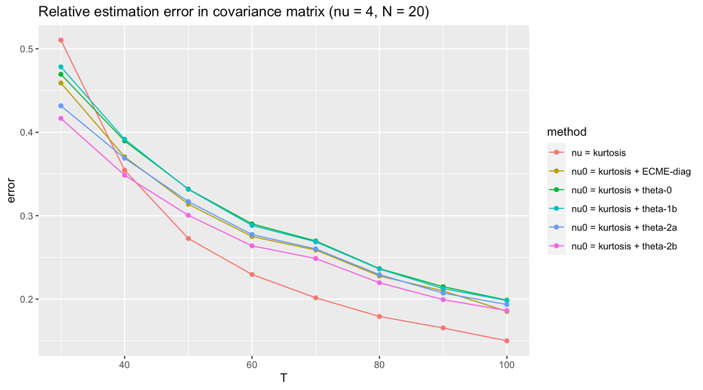

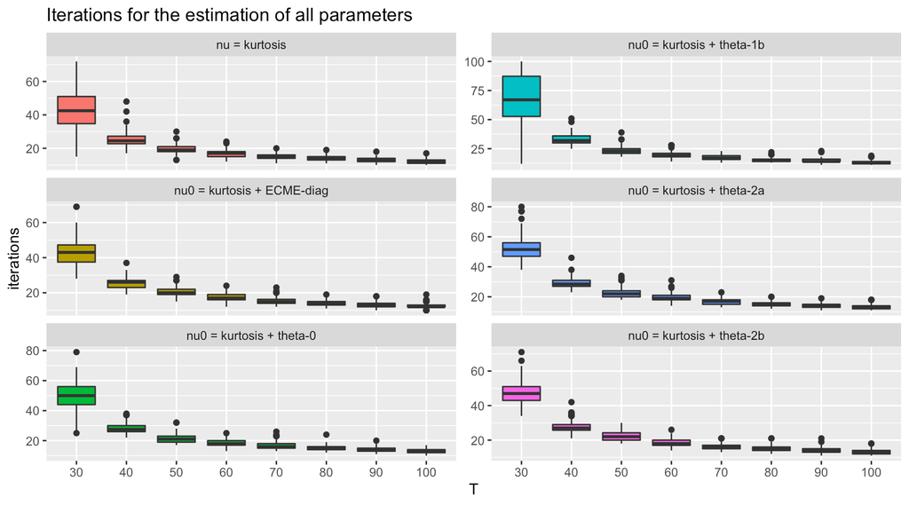

In terms of iterations they all look similar, although the methods that do not update nu are slightly better..

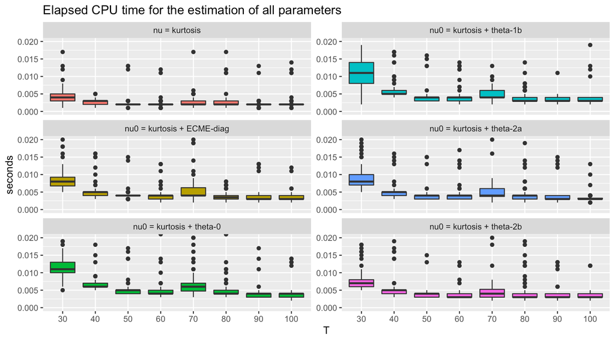

Conclusions:

- The optimization of $\nu$ via the EM algorithm is not stable enough, so better not to use it.
- The three direct estimations “nu = kurtosis”, “nu = MLE-diag”, and “nu = MLE-diag-resampled” give good results. As a consequence, the faster method “nu = kurtosis” will be chosen by default.
- In terms of number of EM iterations, the fixed value or initial point for $\nu$ does not matter that much.
- If $\nu$ is optimized via the EM algorithm, then the initial point is not that relevant and one can simply initialize to $\nu_0 = 4$ with zero computational cost.